# Proyecto Fin de Master

Lucia Rico Cuellar

3 de julio de 2017

Vamos a usar los datos de series mensuales de tráfico en autopistas estatales de peaje, proporcionados por el Ministerio de Fomento del Gobierno de España en su web: http://www.fomento.gob.es/BE/?nivel=2&orden=06000000

Leemos y limpiamos los datos:

Vamos a hacer lo mismo a todos los ficheros, pues tienen la misma estructura (excepto el de los datos globales “Total.”, que no lo usaremos). El fichero de cada autopista contiene datos para hacer 2 tablas, una de datos totales y otra de datos mensuales. Contiene información de la longitud de la autopista, IMD de vehículos pesados y totales y variaciones respecto al año anterior de los IMDs. La función lee_autopista va a borrar columnas y filas sin información, renombrar las columnas, poner los tipos adecuados a cada columnas (pues las columnas que deberían de venir con tipos numéricos no vienen así ni las que deberían de venir en formato fecha) y se va a quedar solamente con los datos mensuales, va a quitar los totales (con los que podría construirse otra tabla, en la función está implementado el código para ello pero no lo devuelve porque de momento no lo usaremos). La función va a devolver sólo las columnas que vamos a estudiar, las fechas e IMD_total. El resto de columnas tienen dependencia lineal con esta columna (variaciones e IMD_pesados), por lo que no aportan información extra.

```r
autopista <- lee_autopista(fread("../dat/06020203_sevilla_cadiz.csv"))
# montmelo_la_junquera <- lee_autopista(fread("../dat/06020101_montmelo_la_junquera.csv"))
```

Empezamos analizando la autopista Sevilla-Cádiz: Vamos a analizar con y sin aplicar logaritmos.

PRIMERO SIN APLICAR LOG. 1-Creo serie temporal:

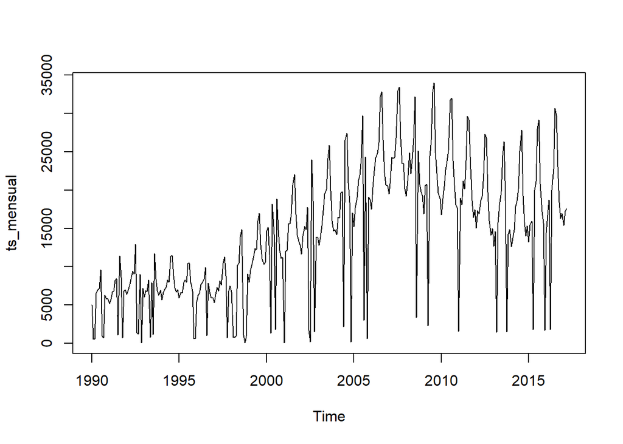

```r
q1 <- autopista
# ts_mensual <- as_xts(q1, date_col = Mes_numeric)
ts_mensual <- ts(autopista$IMD_total, start=c(1990, 1), end=c(2017, 3), frequency=12)
plot(ts_mensual)
```

Summary

```r
summary(ts_mensual)
```

```
##    Min. 1st Qu.  Median    Mean 3rd Qu.    Max.
##      69    7262   14780   14280   20040   33940
```

2-Descomposición estacional:

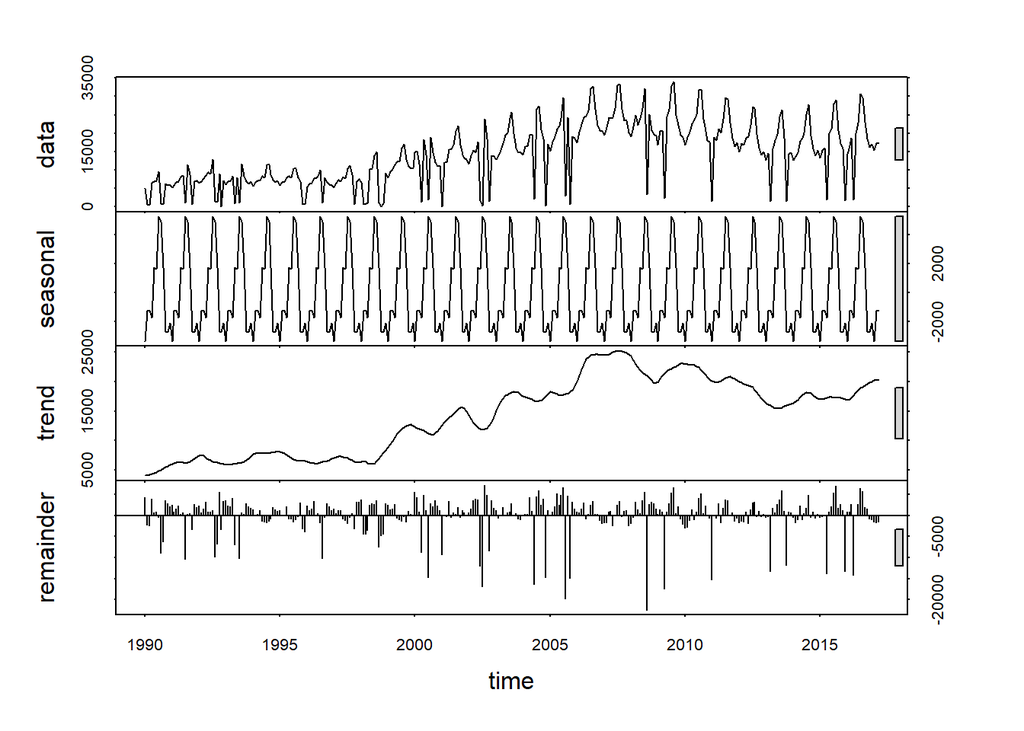

```r
fit <- stl(ts_mensual, s.window="period")
plot(fit)
```

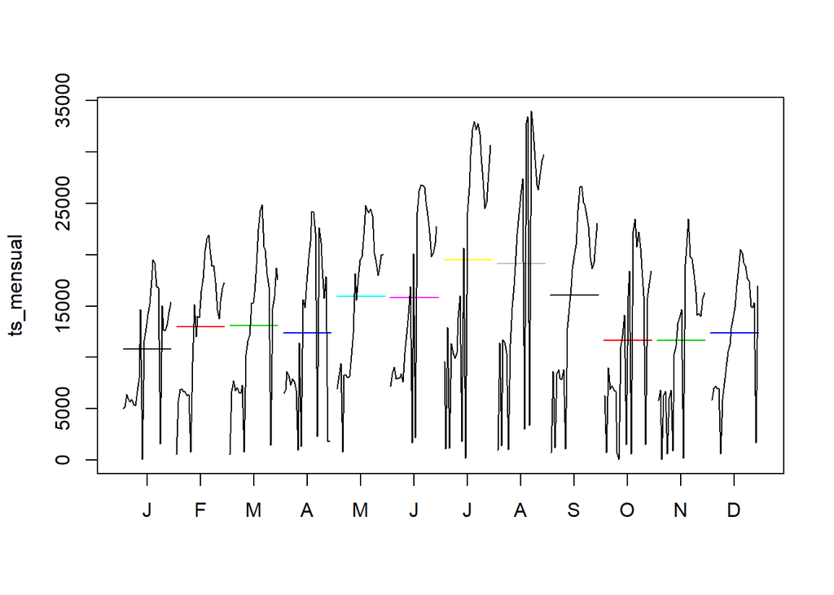

```r
monthplot(ts_mensual, col=1:12, pch=19)
```

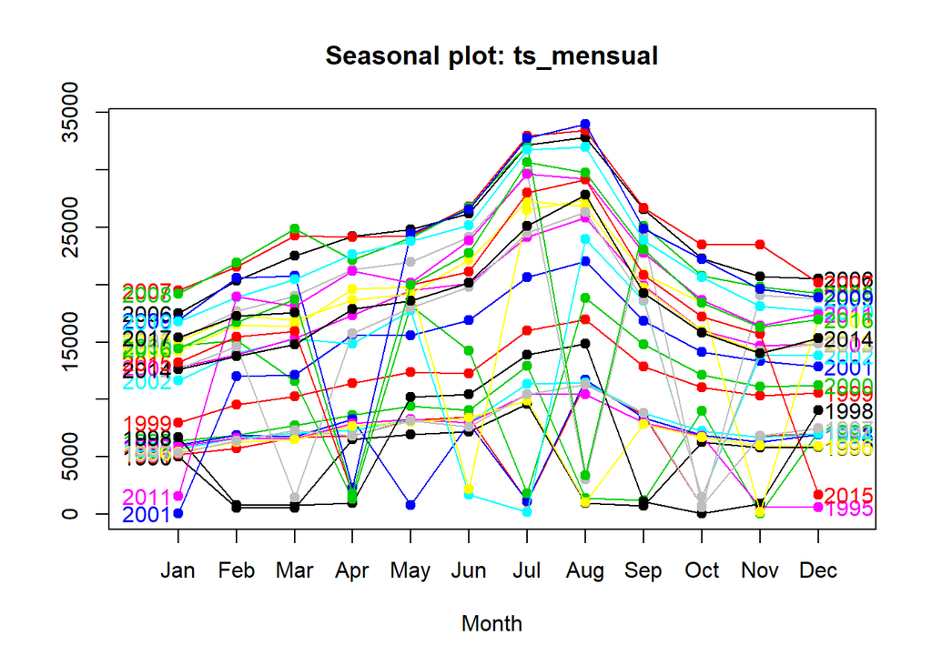

```r
# ts_mensual <- ts(autopista$IMD_total, start=c(1990, 1), end=c(2017, 3), frequency=12)#si no da error por inicio y fin
seasonplot(ts_mensual, year.labels=TRUE, year.labels.left=TRUE, col=1:27, pch=19)
```

Seleccionar 1 ventana de la serie temporal para train y otra para test:

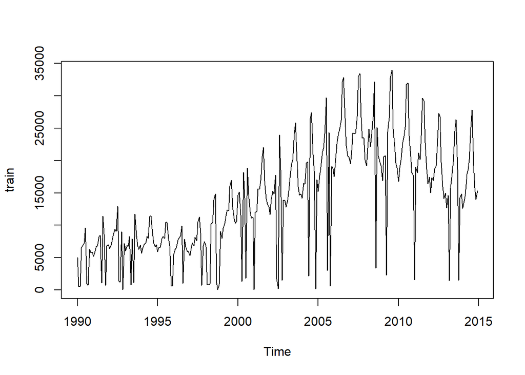

```r
train <- window(ts_mensual, start=c(1990, 01), end=c(2014, 12))
plot(train)
```

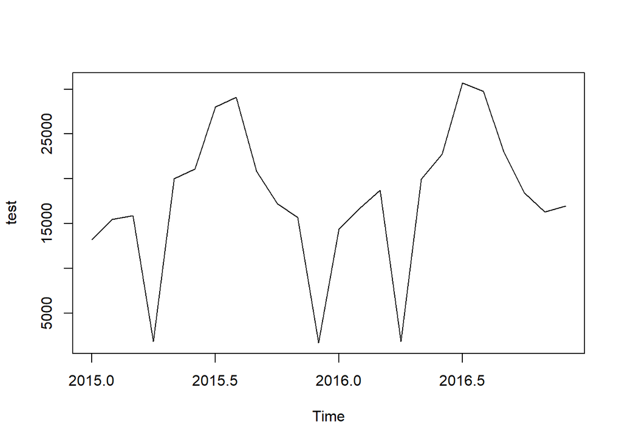

```r
test <- window(ts_mensual, start=c(2015, 01), end=c(2016, 12))
plot(test)
```

3-Modelado exponencial ETS y predicción

```r
fit <- ets(train)
fit
```

```
## ETS(M,A,M)
##
## Call:
##  ets(y = train)
##
##   Smoothing parameters:
##     alpha = 0.1266
##     beta  = 0.001
##     gamma = 1e-04
##
##   Initial states:
##     l = 4333.074
##     b = 193.8799
##     s=0.8561 0.825 0.8851 1.0457 1.3732 1.3397
##            1.0714 1.066 0.9822 0.8913 0.8734 0.7911
##
##   sigma:  0.3533
##
##      AIC     AICc      BIC
## 6795.710 6797.880 6858.674
```

```r
prediccion <- forecast(fit)
```

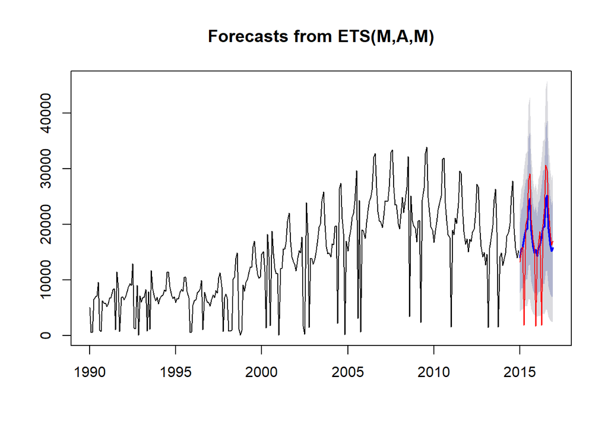

```r
par(mfrow=c(1,1))
plot(prediccion)
lines(test, col="red")
```

Precisión:

```r
accuracy(prediccion,test)
```

```
##                     ME     RMSE      MAE        MPE     MAPE      MASE
## Training set -574.1183 4793.134 2671.221 -230.11831 243.7597 0.6756538
## Test set     -208.6048 5911.918 3658.475  -98.31254 113.1397 0.9253680
##                    ACF1 Theil's U
## Training set 0.02049085        NA
## Test set     0.05127993 0.1104575
```

4-Modelado ARIMA y predicción:

```r
fit2 <- auto.arima(train)
fit2
```

```
## Series: train
## ARIMA(0,1,3)(1,0,2)[12]
##
## Coefficients:
##           ma1      ma2      ma3    sar1     sma1    sma2
##       -0.8092  -0.0475  -0.0467  0.8116  -0.7469  0.1965
## s.e.   0.0648   0.0773   0.0788  0.3325   0.3250  0.2156
##
## sigma^2 estimated as 25416716:  log likelihood=-2973.19
## AIC=5960.37   AICc=5960.76   BIC=5986.27
```

```r
prediccion2 <- forecast(fit2)
prediccion2
```

```
##          Point Forecast     Lo 80    Hi 80     Lo 95    Hi 95
## Jan 2015       12808.21  6347.272 19269.15  2927.056 22689.37
## Feb 2015       15196.20  8618.710 21773.70  5136.795 25255.61
## Mar 2015       11934.26  5291.963 18576.56  1775.742 22092.78
## Apr 2015       16161.86  9490.325 22833.39  5958.630 26365.08
## May 2015       16870.02 10169.384 23570.66  6622.282 27117.76
## Jun 2015       18234.66 11505.049 24964.28  7942.606 28526.72
## Jul 2015       21169.83 14411.365 27928.30 10833.648 31506.02
## Aug 2015       21767.80 14980.601 28555.00 11387.674 32147.93
## Sep 2015       17351.66 10535.854 24167.48  6927.782 27775.55
## Oct 2015       11927.64  5083.341 18771.94  1460.187 22395.10
## Nov 2015       14355.74  7483.068 21228.42  3844.894 24866.59
## Dec 2015       14804.67  7903.745 21705.61  4250.613 25358.74
## Jan 2016       13114.93  6135.777 20094.08  2441.238 23788.62
## Feb 2016       14482.24  7467.705 21496.77  3754.437 25210.03
## Mar 2016       12225.84  5178.061 19273.61  1447.193 23004.48
## Apr 2016       15961.15  8882.148 23040.16  5134.748 26787.56
## May 2016       16529.51  9419.414 23639.62  5655.554 27403.48
## Jun 2016       17617.18 10476.122 24758.24  6695.874 28538.49
## Jul 2016       20349.88 13177.997 27521.76  9381.431 31318.33
## Aug 2016       21383.76 14181.186 28586.34 10368.373 32399.15
## Sep 2016       16930.36  9697.221 24163.50  5868.228 27992.49
## Oct 2016       12433.90  5170.330 19697.48  1325.227 23542.58
## Nov 2016       14112.71  6818.828 21406.59  2957.681 25267.73
## Dec 2016       14663.06  7338.997 21987.12  3461.874 25864.24
```

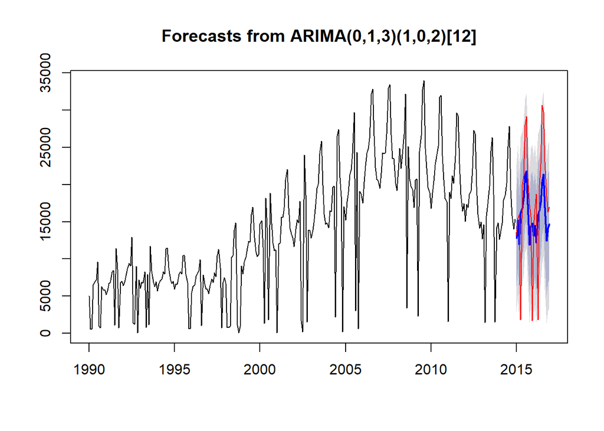

```r
plot(prediccion2)
lines(test, col="red")
```

Precisión:

```r
accuracy(prediccion2,test)
```

```
##                     ME     RMSE      MAE        MPE     MAPE      MASE
## Training set  139.8475 4982.335 3297.273 -213.73225 236.2323 0.8340064
## Test set     1976.8291 6773.495 5438.136  -79.20672 113.3673 1.3755125
##                      ACF1 Theil's U
## Training set -0.001670935        NA
## Test set      0.042816165 0.1996729
```

Comparando con la anterior predice peor el de ARIMA (mayor RMSE).

```r
accuracy(prediccion,test)
```

```
##                     ME     RMSE      MAE        MPE     MAPE      MASE
## Training set -574.1183 4793.134 2671.221 -230.11831 243.7597 0.6756538
## Test set     -208.6048 5911.918 3658.475  -98.31254 113.1397 0.9253680
##                    ACF1 Theil's U
## Training set 0.02049085        NA
## Test set     0.05127993 0.1104575
```

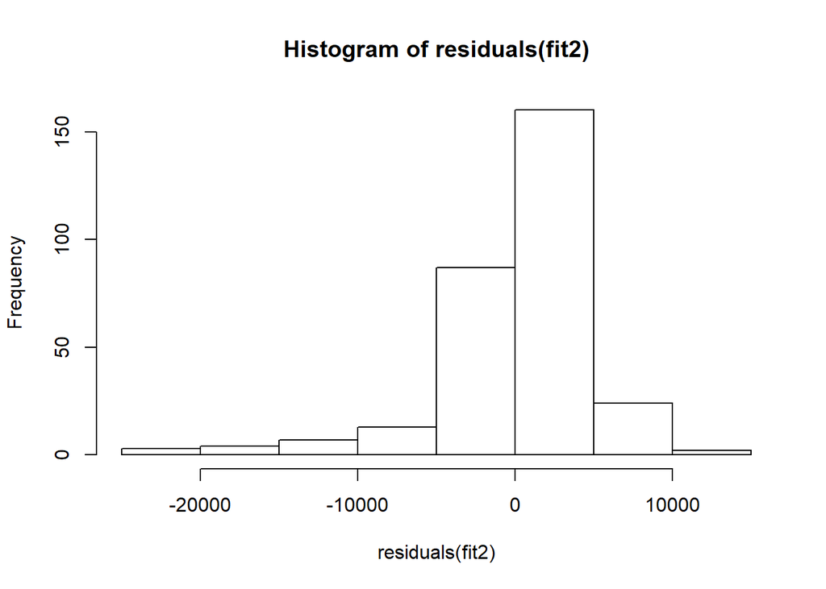

```r
hist(residuals(fit2))
```

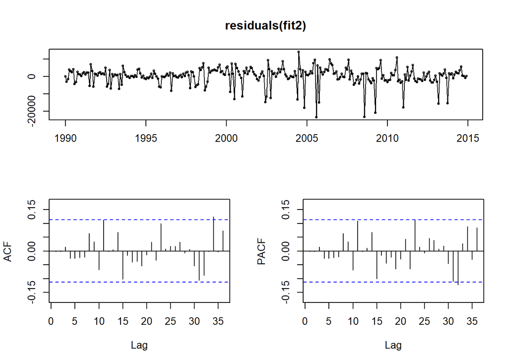

```r
tsdisplay(residuals(fit2))
```

```r
Box.test(residuals(fit2), type="Ljung")
```

```
##
##  Box-Ljung test
##
## data:  residuals(fit2)
## X-squared = 0.00084601, df = 1, p-value = 0.9768
```

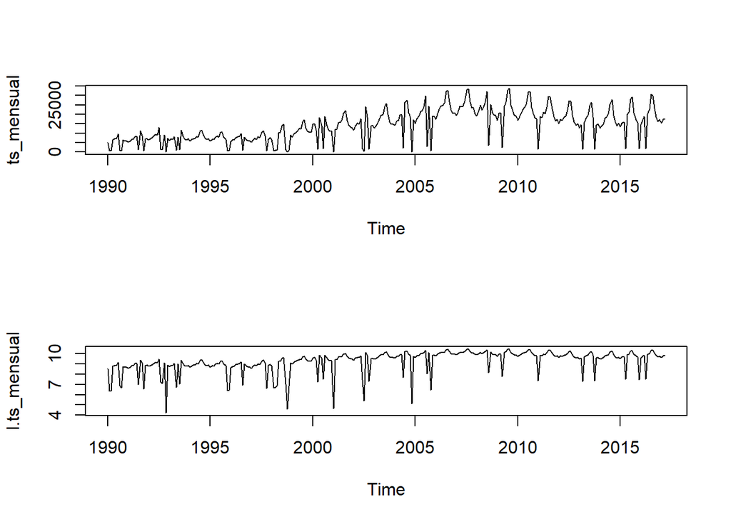

```r
l.ts_mensual <- log(ts_mensual)
par(mfrow=c(2,1))
plot(ts_mensual)
plot(l.ts_mensual)
```

Summary:

```r
summary(l.ts_mensual)
```

```
##    Min. 1st Qu.  Median    Mean 3rd Qu.    Max.
##   4.234   8.890   9.601   9.240   9.905  10.430
```

2-B-Descomposición estacional:

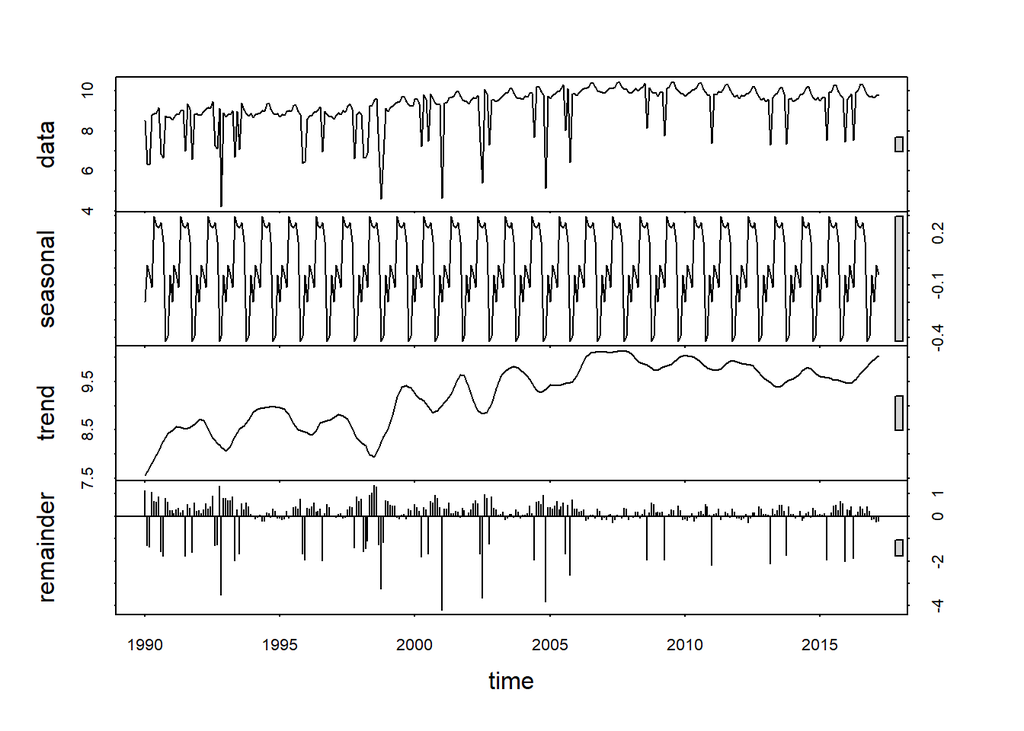

```r
fit <- stl(l.ts_mensual, s.window="period")
plot(fit)
```

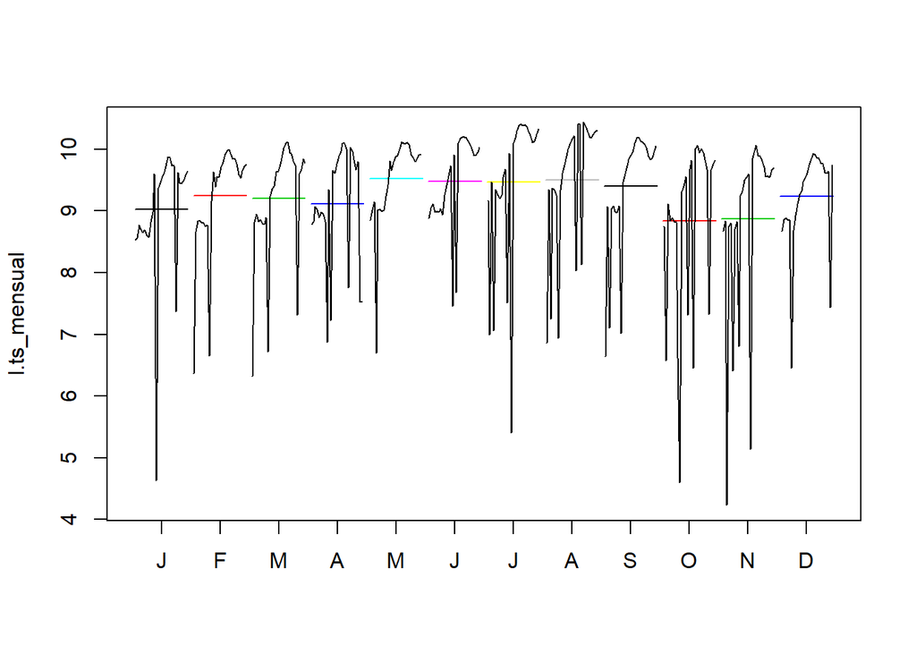

```r
monthplot(l.ts_mensual, col=1:12, pch=19)
```

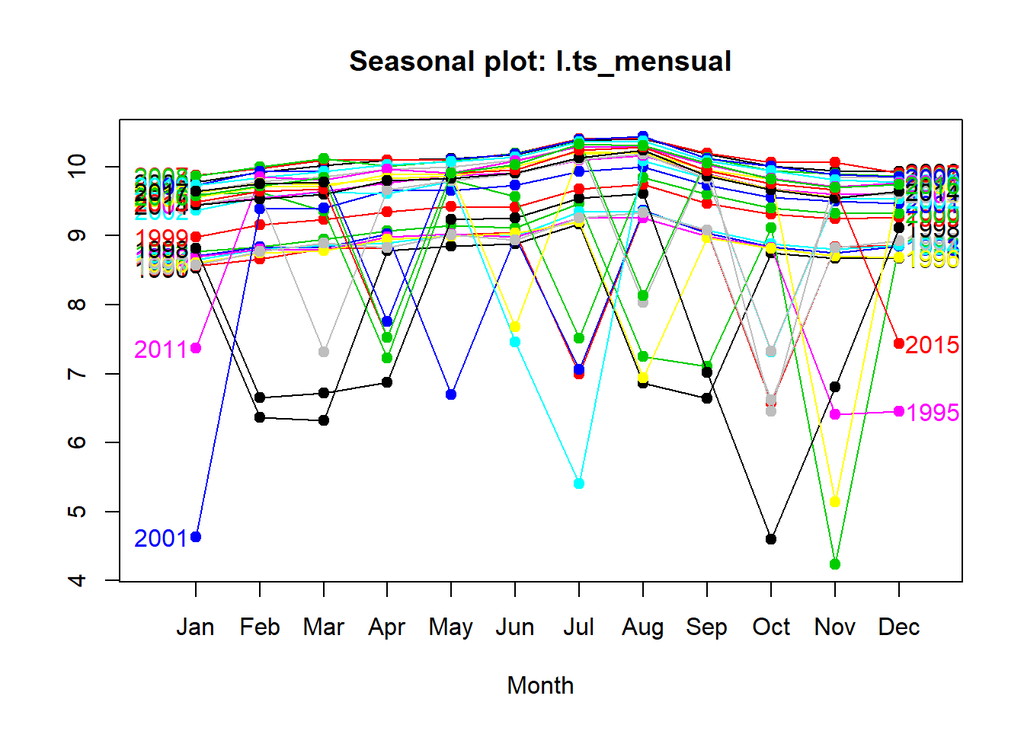

```r
seasonplot(l.ts_mensual, year.labels=TRUE, year.labels.left=TRUE, col=1:27, pch=19)
```

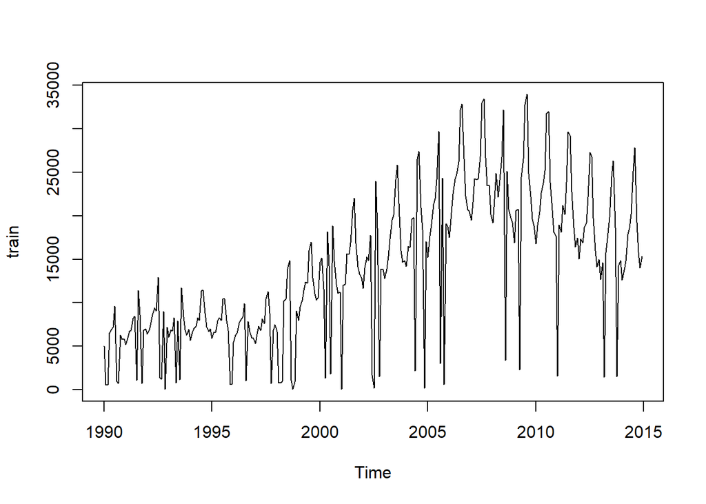

```r
train <- window(ts_mensual, start=c(1990, 01), end=c(2014, 12))
plot(train)
```

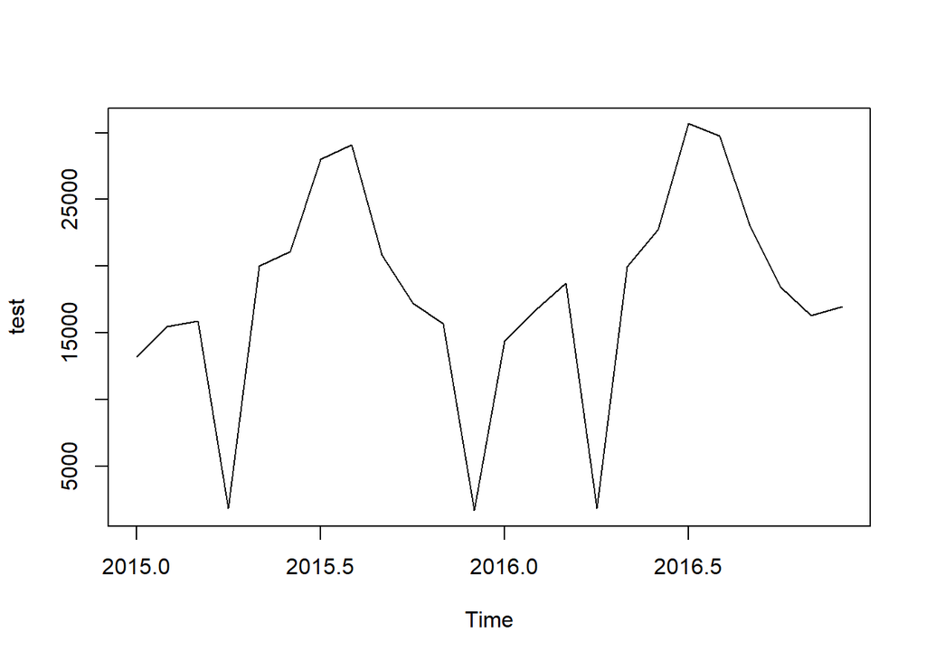

```r
test <- window(ts_mensual, start=c(2015, 01), end=c(2016, 12))
plot(test)
```

```r
fit <- ets(train)
fit
```

```
## ETS(M,A,M)
##
## Call:
##  ets(y = train)
##
##   Smoothing parameters:
##     alpha = 0.1266
##     beta  = 0.001
##     gamma = 1e-04
##
##   Initial states:
##     l = 4333.074
##     b = 193.8799
##     s=0.8561 0.825 0.8851 1.0457 1.3732 1.3397
##            1.0714 1.066 0.9822 0.8913 0.8734 0.7911
##
##   sigma:  0.3533
##
##      AIC     AICc      BIC
## 6795.710 6797.880 6858.674
```

```r
prediccion <- forecast(fit)
```

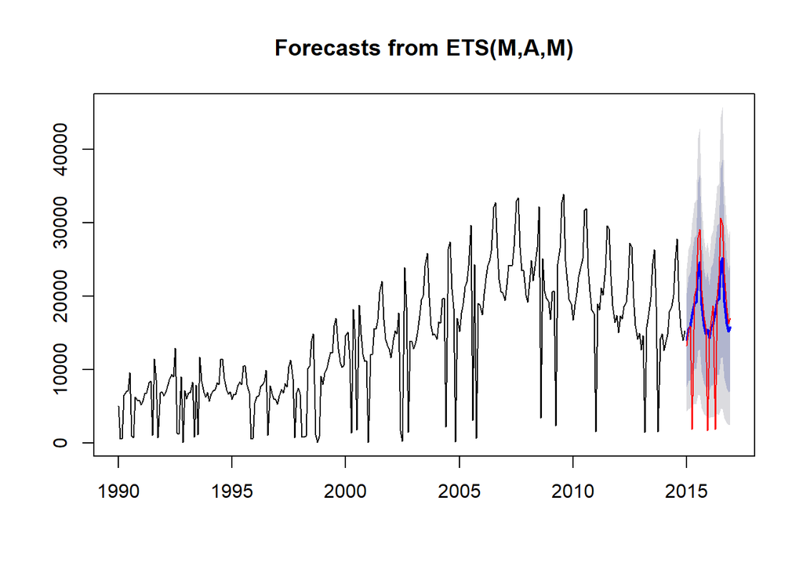

```r
par(mfrow=c(1,1))
plot(prediccion)
lines(test, col="red")
```

Precisión:

```r
accuracy(prediccion,test)
```

```
##                     ME     RMSE      MAE        MPE     MAPE      MASE
## Training set -574.1183 4793.134 2671.221 -230.11831 243.7597 0.6756538
## Test set     -208.6048 5911.918 3658.475  -98.31254 113.1397 0.9253680
##                    ACF1 Theil's U
## Training set 0.02049085        NA
## Test set     0.05127993 0.1104575
```

```r
fit2 <- auto.arima(train)
fit2
```

```
## Series: train
## ARIMA(0,1,3)(1,0,2)[12]
##
## Coefficients:
##           ma1      ma2      ma3    sar1     sma1    sma2
##       -0.8092  -0.0475  -0.0467  0.8116  -0.7469  0.1965
## s.e.   0.0648   0.0773   0.0788  0.3325   0.3250  0.2156
##
## sigma^2 estimated as 25416716:  log likelihood=-2973.19
## AIC=5960.37   AICc=5960.76   BIC=5986.27
```

```r
prediccion2 <- forecast(fit2)
prediccion2
```

```
##          Point Forecast     Lo 80    Hi 80     Lo 95    Hi 95
## Jan 2015       12808.21  6347.272 19269.15  2927.056 22689.37
## Feb 2015       15196.20  8618.710 21773.70  5136.795 25255.61
## Mar 2015       11934.26  5291.963 18576.56  1775.742 22092.78
## Apr 2015       16161.86  9490.325 22833.39  5958.630 26365.08
## May 2015       16870.02 10169.384 23570.66  6622.282 27117.76
## Jun 2015       18234.66 11505.049 24964.28  7942.606 28526.72
## Jul 2015       21169.83 14411.365 27928.30 10833.648 31506.02
## Aug 2015       21767.80 14980.601 28555.00 11387.674 32147.93
## Sep 2015       17351.66 10535.854 24167.48  6927.782 27775.55
## Oct 2015       11927.64  5083.341 18771.94  1460.187 22395.10
## Nov 2015       14355.74  7483.068 21228.42  3844.894 24866.59
## Dec 2015       14804.67  7903.745 21705.61  4250.613 25358.74
## Jan 2016       13114.93  6135.777 20094.08  2441.238 23788.62
## Feb 2016       14482.24  7467.705 21496.77  3754.437 25210.03
## Mar 2016       12225.84  5178.061 19273.61  1447.193 23004.48
## Apr 2016       15961.15  8882.148 23040.16  5134.748 26787.56
## May 2016       16529.51  9419.414 23639.62  5655.554 27403.48
## Jun 2016       17617.18 10476.122 24758.24  6695.874 28538.49
## Jul 2016       20349.88 13177.997 27521.76  9381.431 31318.33
## Aug 2016       21383.76 14181.186 28586.34 10368.373 32399.15
## Sep 2016       16930.36  9697.221 24163.50  5868.228 27992.49
## Oct 2016       12433.90  5170.330 19697.48  1325.227 23542.58
## Nov 2016       14112.71  6818.828 21406.59  2957.681 25267.73
## Dec 2016       14663.06  7338.997 21987.12  3461.874 25864.24
```

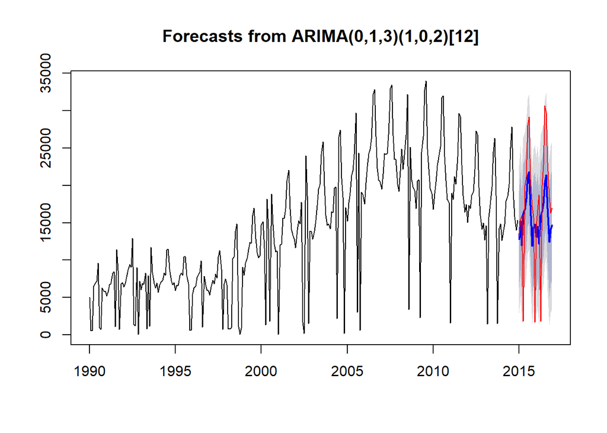

```r
plot(prediccion2)
lines(test, col="red")
```

Precisión:

```r
accuracy(prediccion2,test)
```

```
##                     ME     RMSE      MAE        MPE     MAPE      MASE
## Training set  139.8475 4982.335 3297.273 -213.73225 236.2323 0.8340064
## Test set     1976.8291 6773.495 5438.136  -79.20672 113.3673 1.3755125
##                      ACF1 Theil's U
## Training set -0.001670935        NA
## Test set      0.042816165 0.1996729
```

```r
accuracy(prediccion,test)
```

```
##                     ME     RMSE      MAE        MPE     MAPE      MASE
## Training set -574.1183 4793.134 2671.221 -230.11831 243.7597 0.6756538
## Test set     -208.6048 5911.918 3658.475  -98.31254 113.1397 0.9253680
##                    ACF1 Theil's U
## Training set 0.02049085        NA
## Test set     0.05127993 0.1104575
```

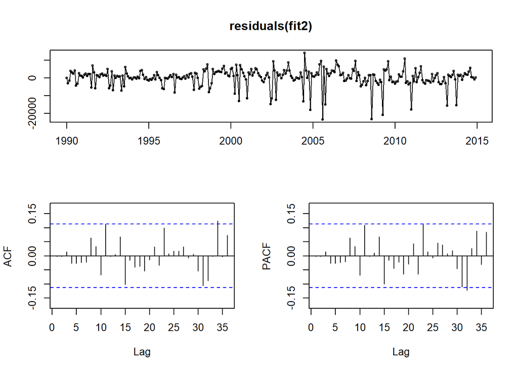

```r
tsdisplay(residuals(fit2))
```

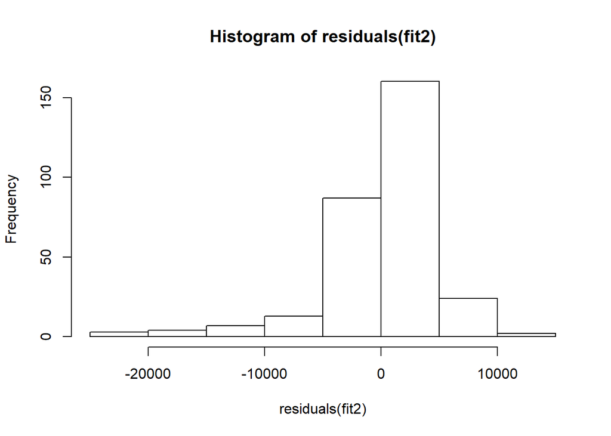

```r
hist(residuals(fit2))
```

```r
Box.test(residuals(fit2),  type="Ljung")
```

```
##
##  Box-Ljung test
##
## data:  residuals(fit2)
## X-squared = 0.00084601, df = 1, p-value = 0.9768
```

```r
#
```